# Time Series Decomposition

Jack K. Rasmus-Vorrath

July 27, 2017

# The following analysis and visualization performs classical and STL decomposition of time series data on passenger vehicle production in the United Kingdom.

## Data Import from ‘FPP’ Library & Time Series Visualization

```r
library(fpp)
```

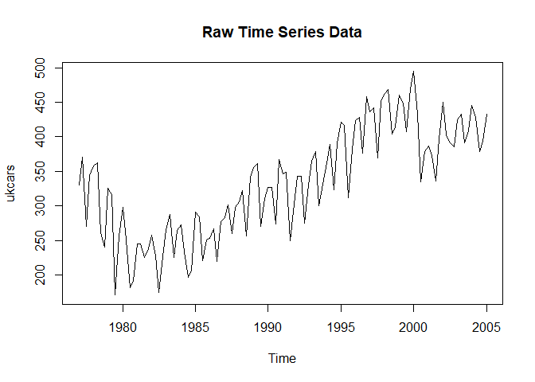

```r
data(ukcars)
plot(ukcars, main = "Raw Time Series Data")
```

## Classical Decomposition

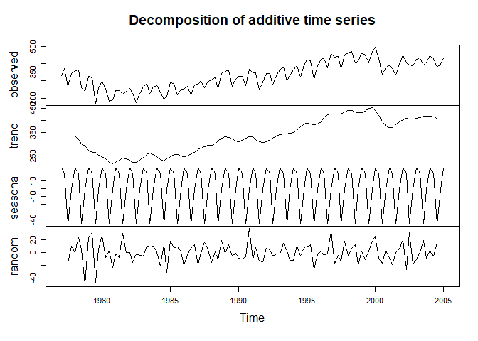

```r
fitd <- decompose(ukcars)
plot(fitd)
```

## Seasonal Adjustment

### The analysis proceeded by computing and plotting the seasonally adjusted data, which no longer exhibits the characteristic annual peak-and-valley pattern of variation.

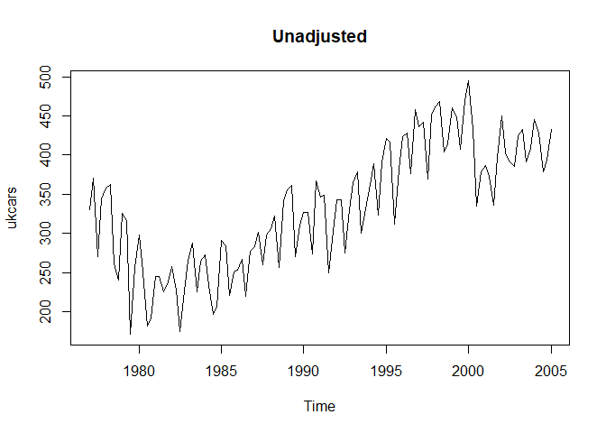

```r
cars_adj <- seasadj(fitd)
plot(ukcars, main = "Unadjusted")
```

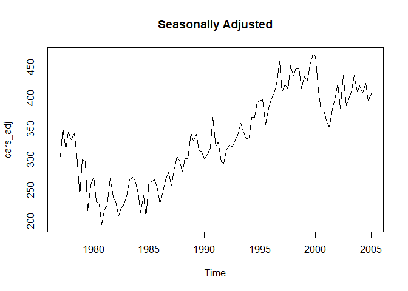

```r
plot(cars_adj, main = "Seasonally Adjusted")
```

## EDA: Outlier Effects

### To observe its effects, an outlying value (+500) was added to the data for 1993 Q3 before recomputing the seasonal adjustment, which leaves intact the unusual (non-seasonal) peak of the data point in the subsequent comparative visualization.

```r
cars2 <- ts(c(ukcars[1:66],ukcars[67]+500,ukcars[68:113]),start=c(1977,1),frequency=4)

ukcars[65:68]
```

```
## [1] 364.521 378.448 300.798 331.757
```

```r
#Now becomes:

cars2[65:68]
```

```
## [1] 364.521 378.448 800.798 331.757
```

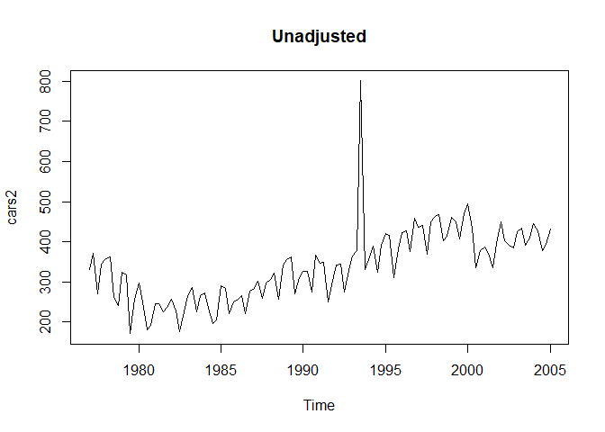

```r
fitd2 <- decompose(cars2)
cars_adj2 <- seasadj(fitd2)

plot(cars2, main = "Unadjusted")
```

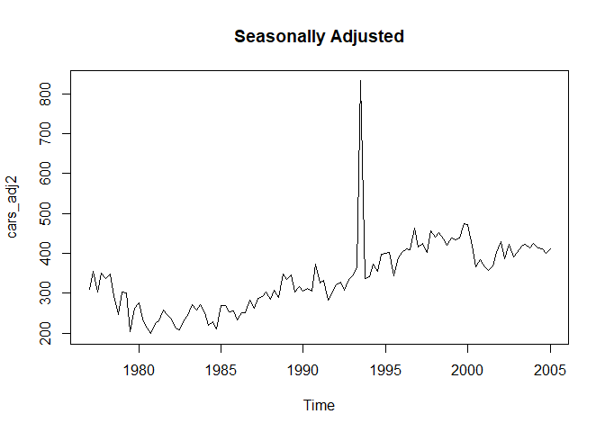

```r
plot(cars_adj2, main = "Seasonally Adjusted")
```

## EDA (Part 2): Outlier Effects

### By comparison, the outlying value (+500) was instead added to the data for 2004 Q2 before recomputing the seasonal adjustment, which reproduces the same unusual peak at the end of the time series. While calculation of a moving average may be affected by the location of an outlier with respect to a given time window, the seasonal adjustment is made to the entire length of time series, leaving the effect unaltered.

```r
cars3 <- ts(c(ukcars[1:109],ukcars[110]+500,ukcars[111:113]),start=c(1977,1),frequency=4)

ukcars[109:112]
```

```
## [1] 445.458 428.202 379.048 394.042
```

```r
#Now becomes:

cars3[109:112]
```

```
## [1] 445.458 928.202 379.048 394.042
```

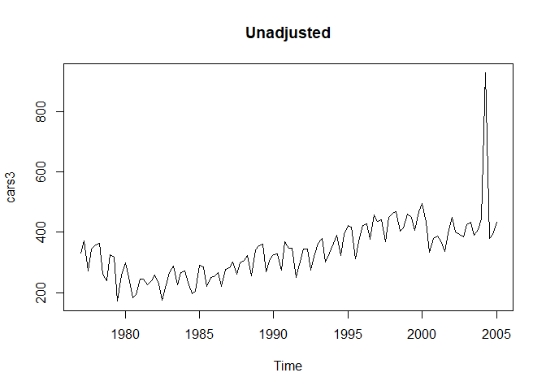

```r
fitd3 <- decompose(cars3)
cars_adj3 <- seasadj(fitd3)

plot(cars3, main = "Unadjusted")
```

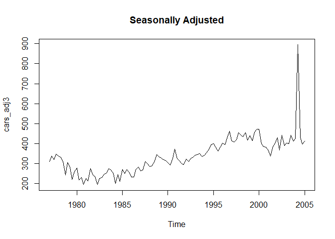

```r
plot(cars_adj3, main = "Seasonally Adjusted")
```

## STL Decomposition

### As a final evaluation of features of the time series, seasonal and trend decomposition was performed using locally estimated scatterplot smoothing (LOESS), producing the comparative visualization of the three time series below.

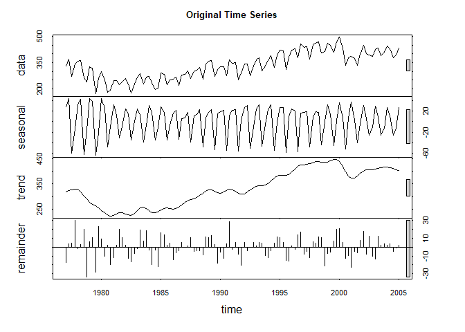

```r
fit <- stl(ukcars, s.window = 5)
fit2 <- stl(cars2, s.window = 5)
fit3 <- stl(cars3, s.window = 5)

plot(fit, main = "Original Time Series")
```

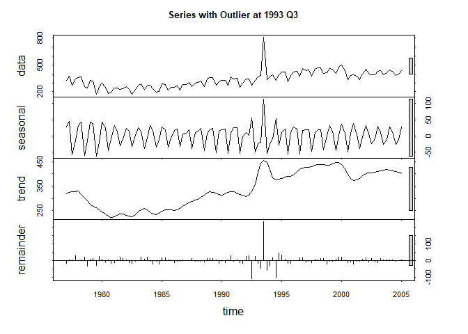

```r
plot(fit2, main = "Series with Outlier at 1993 Q3")
```

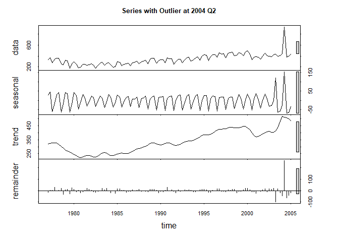

```r
plot(fit3, main = "Series with Outlier at 2004 Q2")
```

## For comparative visual assessment, overlaid fits of STL decomposition are applied to the original time series data, and to the two series including artificial outliers as well.

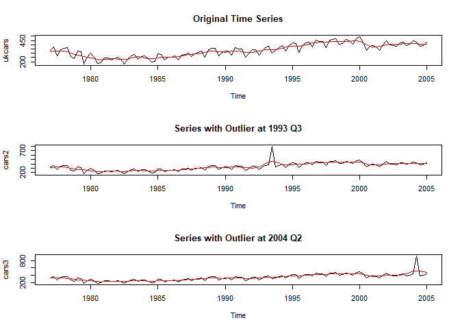

```r
par(mfrow = c(3,1))

plot(ukcars, main = "Original Time Series")
lines(fit$time.series[,2],col="red",ylab="Trend")

plot(cars2, main = "Series with Outlier at 1993 Q3")
lines(fit2$time.series[,2],col="red",ylab="Trend")

plot(cars3, main = "Series with Outlier at 2004 Q2")
lines(fit3$time.series[,2],col="red",ylab="Trend")
```